# HW 05 Soultions

Elijah Willie

November 08, 2018

# Introduction

In this assignment, I will attempt to do the following tasks:

- Writing functions that are useful to analyze the gapminder dataset
- Work with a nested data frame

## Load in required libraries

First we will load in all the libraries we will be using for this assignment.

```r
library(gapminder)
suppressMessages(library("tidyverse"))
library(knitr)
suppressMessages(library(reshape2))
suppressMessages(library(Hmisc))
suppressMessages(library(gridExtra))
library(knitr)
suppressMessages(library(MASS))
suppressMessages(library(broom))
```

## Part 1: Writing Functions

### For this section, I will do the following:

- Fit a model model linear model that predicts `life expectancy` for `year`, `pop` or `gdpPercap` for a given country.
- Create a function to plot a linear fit

#### Create a function that fits a linear model

```r
fit_model <- function(Country, variable, data){
#extract the data for the specific country
data_country <-  as.data.frame(data) %>%
  filter(country == Country)

#fit the model
if(variable == "pop"){
  model_fit <- lm(lifeExp ~ pop, data_country)
}
if(variable == "gdpPercap"){
  model_fit  <- lm(lifeExp ~ gdpPercap, data_country)
}
if(variable == "year"){
  model_fit <- lm(lifeExp ~ year, data_country)
}

return(model_fit)
}
```

#### Create a function that plots the a given regression fit

```r
plotReg <- function (fit) {

require(ggplot2)

p <- ggplot(fit$model, aes_string(x = names(fit$model)[2], y = names(fit$model)[1])) +
  geom_point() +
  stat_smooth(method = "lm", col = "red") +
  labs(title = paste("Intercept =",signif(fit$coef[[1]],5 ),
                     " Slope =",signif(fit$coef[[2]], 5),
                     " P =",signif(summary(fit)$coef[2,4], 5)))
return(p)
}
```

#### Test out the functions

Predict life expectancy for `Liberia` and `Ghana` using population.

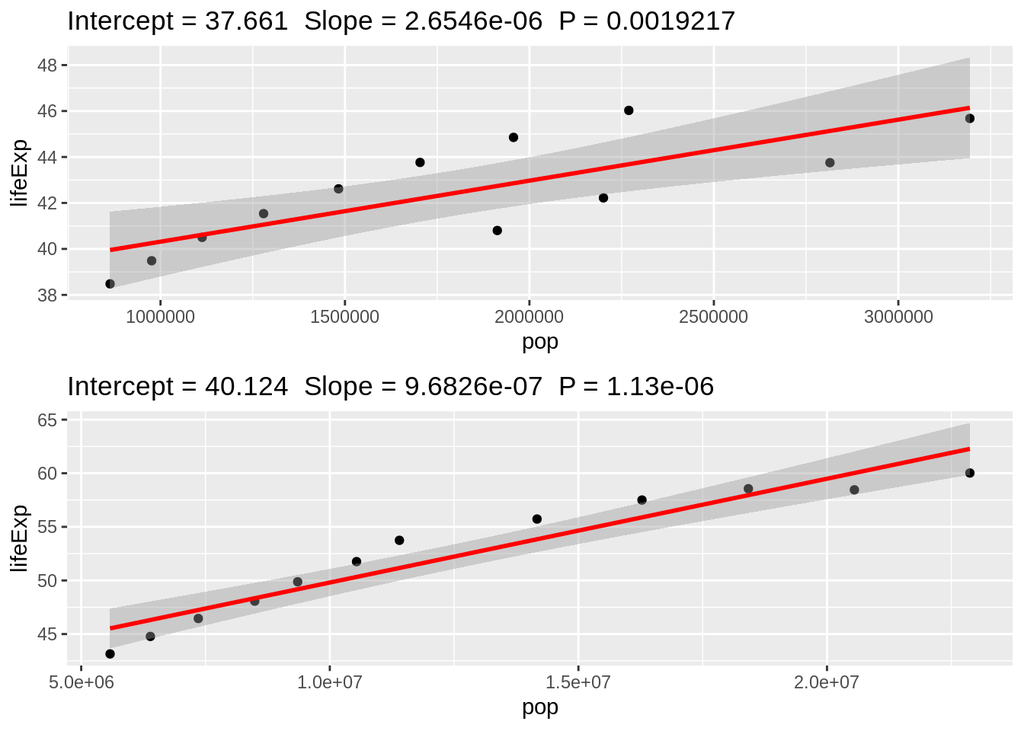

```r
#create a set of countries
countries <- c("Liberia", "Ghana")

#fit a linear model using population
res <- lapply(countries, fit_model, variable = "pop", data = gapminder)

#generate the plots
plots <- lapply(res, plotReg)

#put them on a grid
grid.arrange(plots[[1]], plots[[2]])
```

Looking at the plots above, we see that population does a much better job at predicting life expectancy when for `Ghana` When compared with `Liberia`.

Now predict again, but this time use `gdpPercap`

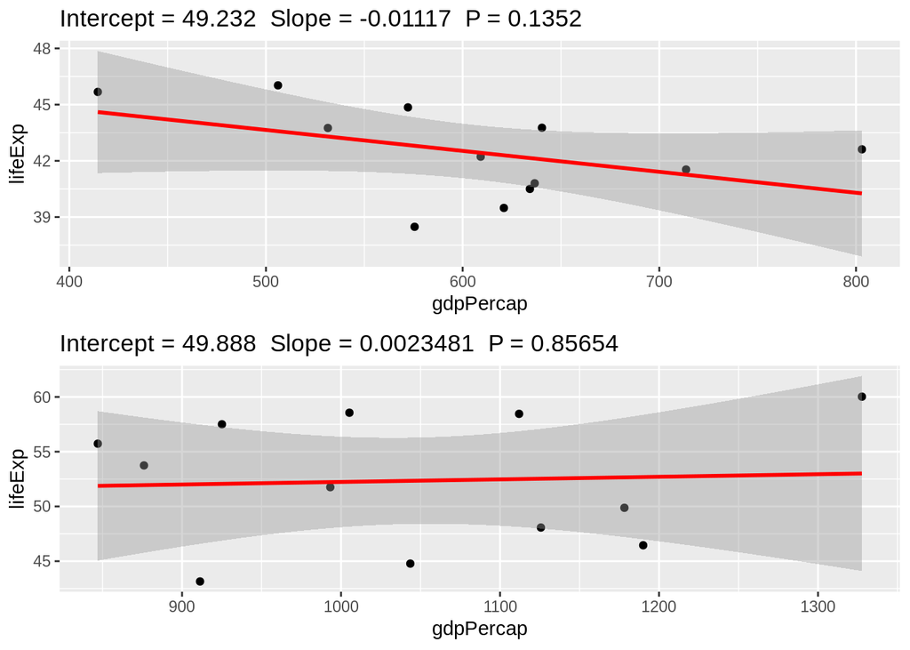

```r
#fit a linear model using gdpPercap
res <- lapply(countries, fit_model, variable = "gdpPercap", data = gapminder)

#generate the plots
plots <- lapply(res, plotReg)

#put them on a grid
grid.arrange(plots[[1]], plots[[2]])
```

Here we see that `gdpPercap` does a pretty terrible job at predicting life xpectancy. Maybe using year would help.

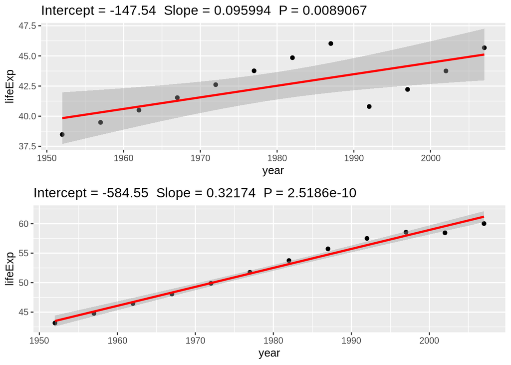

```r
#fit a linear model using population
res <- lapply(countries, fit_model, variable = "year", data = gapminder)

#generate the plots
plots <- lapply(res, plotReg)

#put them on a grid
grid.arrange(plots[[1]], plots[[2]])
```

That is much better indeed. We still see that it performs much better for `Ghana` than `Liberia`.

## Part 2 Work with a nested data frame

In the part, I will attempt to do the following

- Nest the data by country (and continent).
- Fit a model of life expectancy against year. Possibly quadratic, possibly robust.
- Use functions for working with fitted models or the `broom` package to get information out of your linear models.
- Use the usual dplyr, tidyr, and ggplot2 workflows to explore, e.g., the estimated cofficients.
- I will be following the tutorial [here](http://stat545.com/block024_group-nest-split-map.html) closely, but with my own twists and turns.

```r
#nest the gapminder dataset by country and continent
gap_nested <- gapminder %>%
   group_by(continent, country) %>%
   nest()

#lets get some information on the new dataset
gap_nested
```

```
## # A tibble: 142 x 3
##    continent country     data
##    <fct>     <fct>       <list>
##  1 Asia      Afghanistan <tibble [12 × 4]>
##  2 Europe    Albania     <tibble [12 × 4]>
##  3 Africa    Algeria     <tibble [12 × 4]>
##  4 Africa    Angola      <tibble [12 × 4]>
##  5 Americas  Argentina   <tibble [12 × 4]>
##  6 Oceania   Australia   <tibble [12 × 4]>
##  7 Europe    Austria     <tibble [12 × 4]>
##  8 Asia      Bahrain     <tibble [12 × 4]>
##  9 Asia      Bangladesh  <tibble [12 × 4]>
## 10 Europe    Belgium     <tibble [12 × 4]>
## # ... with 132 more rows
```

```r
nrow(gap_nested)
```

```
## [1] 142
```

```r
ncol(gap_nested)
```

```
## [1] 3
```

We see that the new dataframe has $142$ rows and $3$ columns

Now lets take a look at some of the elements of the new nested dataframe

```r
#we can use indices to get information about the data
kable(gap_nested[[1, "data"]])
```

| year | lifeExp | pop | gdpPercap |
| --- | --- | --- | --- |
| 1952 | 28.801 | 8425333 | 779.4453 |
| 1957 | 30.332 | 9240934 | 820.8530 |
| 1962 | 31.997 | 10267083 | 853.1007 |
| 1967 | 34.020 | 11537966 | 836.1971 |
| 1972 | 36.088 | 13079460 | 739.9811 |
| 1977 | 38.438 | 14880372 | 786.1134 |
| 1982 | 39.854 | 12881816 | 978.0114 |
| 1987 | 40.822 | 13867957 | 852.3959 |
| 1992 | 41.674 | 16317921 | 649.3414 |
| 1997 | 41.763 | 22227415 | 635.3414 |
| 2002 | 42.129 | 25268405 | 726.7341 |
| 2007 | 43.828 | 31889923 | 974.5803 |

```r
#let see if we can get the country
gap_nested$country[[1]]
```

```
## [1] Afghanistan
## 142 Levels: Afghanistan Albania Algeria Angola Argentina ... Zimbabwe
```

```r
#we can even get data for a specific country
gap_nested[gap_nested$country == "Liberia",][["data"]]
```

```
## [[1]]
## # A tibble: 12 x 4
##     year lifeExp     pop gdpPercap
##    <int>   <dbl>   <int>     <dbl>
##  1  1952    38.5  863308      576.
##  2  1957    39.5  975950      621.
##  3  1962    40.5 1112796      634.
##  4  1967    41.5 1279406      714.
##  5  1972    42.6 1482628      803.
##  6  1977    43.8 1703617      640.
##  7  1982    44.9 1956875      572.
##  8  1987    46.0 2269414      506.
##  9  1992    40.8 1912974      637.
## 10  1997    42.2 2200725      609.
## 11  2002    43.8 2814651      531.
## 12  2007    45.7 3193942      415.
```

```r
#lets try it for another country
gap_nested[gap_nested$country == "Ghana",][["data"]]
```

```
## [[1]]
## # A tibble: 12 x 4
##     year lifeExp      pop gdpPercap
##    <int>   <dbl>    <int>     <dbl>
##  1  1952    43.1  5581001      911.
##  2  1957    44.8  6391288     1044.
##  3  1962    46.5  7355248     1190.
##  4  1967    48.1  8490213     1126.
##  5  1972    49.9  9354120     1178.
##  6  1977    51.8 10538093      993.
##  7  1982    53.7 11400338      876.
##  8  1987    55.7 14168101      847.
##  9  1992    57.5 16278738      925.
## 10  1997    58.6 18418288     1005.
## 11  2002    58.5 20550751     1112.
## 12  2007    60.0 22873338     1328.
```

Now lets fit some models to the data and see how they behave

```r
#fit a linear model
lin_fit <- lm(lifeExp ~ year, data = gap_nested[[1, "data"]])
paste("linear fit summary: ")
```

```
## [1] "linear fit summary: "
```

```r
summary(lin_fit)
```

```
##
## Call:
## lm(formula = lifeExp ~ year, data = gap_nested[[1, "data"]])
##
## Residuals:
##     Min      1Q  Median      3Q     Max
## -1.5447 -0.9905 -0.2757  0.8847  1.6868
##
## Coefficients:
##               Estimate Std. Error t value Pr(>|t|)
## (Intercept) -507.53427   40.48416  -12.54 1.93e-07 ***
## year           0.27533    0.02045   13.46 9.84e-08 ***
## ---
## Signif. codes:  0 '***' 0.001 '**' 0.01 '*' 0.05 '.' 0.1 ' ' 1
##
## Residual standard error: 1.223 on 10 degrees of freedom
## Multiple R-squared:  0.9477, Adjusted R-squared:  0.9425
## F-statistic: 181.2 on 1 and 10 DF,  p-value: 9.835e-08
```

```r
#compute the AIC and BIC for this model
paste("linear fit AIC and BIC are: ", AIC(lin_fit), BIC(lin_fit))
```

```
## [1] "linear fit AIC and BIC are:  42.6938696916089 44.1485896409729"
```

```r
#fit a quadratic
quad_fit <- lm(lifeExp ~ poly(year, 2), data = gap_nested[[1, "data"]])
paste("Quad fit summary: ")
```

```
## [1] "Quad fit summary: "
```

```r
summary(quad_fit)
```

```
##
## Call:
## lm(formula = lifeExp ~ poly(year, 2), data = gap_nested[[1, "data"]])
##
## Residuals:
##      Min       1Q   Median       3Q      Max
## -0.75900 -0.51487  0.02653  0.51654  0.62231
##
## Coefficients:
##                Estimate Std. Error t value Pr(>|t|)
## (Intercept)     37.4788     0.1691 221.693  < 2e-16 ***
## poly(year, 2)1  16.4623     0.5856  28.110 4.44e-10 ***
## poly(year, 2)2  -3.4446     0.5856  -5.882 0.000234 ***
## ---
## Signif. codes:  0 '***' 0.001 '**' 0.01 '*' 0.05 '.' 0.1 ' ' 1
##
## Residual standard error: 0.5856 on 9 degrees of freedom
## Multiple R-squared:  0.9892, Adjusted R-squared:  0.9868
## F-statistic: 412.4 on 2 and 9 DF,  p-value: 1.41e-09
```

```r
#compute the AIC and BIC for this model
paste("Quad fit AIC and BIC are: ", AIC(lin_fit), BIC(lin_fit))
```

```
## [1] "Quad fit AIC and BIC are:  42.6938696916089 44.1485896409729"
```

```r
#fit a robust regression
#note that we will need to use the MASS library to do this
robust_fit <- rlm(lifeExp ~ year, data = gap_nested[[1, "data"]])
paste("Robust fit summary: ")
```

```
## [1] "Robust fit summary: "
```

```r
summary(robust_fit)
```

```
##
## Call: rlm(formula = lifeExp ~ year, data = gap_nested[[1, "data"]])
## Residuals:
##     Min      1Q  Median      3Q     Max
## -1.5447 -0.9905 -0.2757  0.8847  1.6868
##
## Coefficients:
##             Value     Std. Error t value
## (Intercept) -507.5343   40.4842   -12.5366
## year           0.2753    0.0205    13.4629
##
## Residual standard error: 1.526 on 10 degrees of freedom
```

```r
#compute the AIC and BIC for this model
paste("Robust fit AIC and BIC are: ",AIC(robust_fit), BIC(robust_fit))
```

```
## [1] "Robust fit AIC and BIC are:  42.6938696916086 44.1485896409726"
```